# Programming Assignment

## Summary Statistics

### Summary Statistics and Boulder, Colorado Weather Data in 2017

After completion of this assignment you will be able to :

- Use Pandas to compute summary statistics on Boulder weather data
- Figure out how summary statistics like mean and standard deviation change under transformations of the data

Go ahead and load Numpy and Pandas using their common aliases, `np` and `pd`.

```python
import numpy as np
import pandas as pd
```

The data we'll explore in this notebook concerns temperatures and other weather observations in Boulder County over the month of July 2017.

The data was obtained from the National Oceanic and Atmospheric Administration's [Climate.gov](https://www.climate.gov/) website. You can find and download loads of climate-related data from NOAA [here](https://www.climate.gov/maps-data/datasets).

The data is stored in a .csv file called `clean_boulder_weather.csv`.

```python
# Two different paths to the data
local_path = 'clean_boulder_weather.csv'

# Load the data into a DataFrame
df = pd.read_csv(local_path)
```

Take a look at the first 50 or so rows of the DataFrame using the `head( )` method.

```python
df.head(50)
```

|  | STATION | NAME | DATE | PRCP | TMAX | TMIN |
| --- | --- | --- | --- | --- | --- | --- |
| 0 | USW00094075 | BOULDER 14 W, CO US | 2017-07-01 | 0.00 | 68.0 | 31.0 |
| 1 | USW00094075 | BOULDER 14 W, CO US | 2017-07-02 | 0.00 | 73.0 | 35.0 |
| 2 | USW00094075 | BOULDER 14 W, CO US | 2017-07-03 | 0.00 | 68.0 | 46.0 |
| 3 | USW00094075 | BOULDER 14 W, CO US | 2017-07-04 | 0.05 | 68.0 | 43.0 |
| 4 | USW00094075 | BOULDER 14 W, CO US | 2017-07-05 | 0.01 | 73.0 | 40.0 |
| 5 | USW00094075 | BOULDER 14 W, CO US | 2017-07-06 | 0.00 | 76.0 | 48.0 |
| 6 | USW00094075 | BOULDER 14 W, CO US | 2017-07-07 | 0.02 | 74.0 | 43.0 |
| 7 | USW00094075 | BOULDER 14 W, CO US | 2017-07-08 | 0.00 | 65.0 | 44.0 |
| 8 | USW00094075 | BOULDER 14 W, CO US | 2017-07-09 | 0.01 | 73.0 | 39.0 |
| 9 | USW00094075 | BOULDER 14 W, CO US | 2017-07-10 | 0.01 | 75.0 | 44.0 |
| 10 | USW00094075 | BOULDER 14 W, CO US | 2017-07-11 | 0.01 | 71.0 | 52.0 |
| 11 | USW00094075 | BOULDER 14 W, CO US | 2017-07-12 | 0.10 | 54.0 | 43.0 |
| 12 | USW00094075 | BOULDER 14 W, CO US | 2017-07-13 | 0.00 | 67.0 | 41.0 |
| 13 | USW00094075 | BOULDER 14 W, CO US | 2017-07-14 | 0.00 | 67.0 | 39.0 |
| 14 | USW00094075 | BOULDER 14 W, CO US | 2017-07-15 | 0.00 | 65.0 | 40.0 |
| 15 | USW00094075 | BOULDER 14 W, CO US | 2017-07-16 | 0.05 | 68.0 | 38.0 |
| 16 | USW00094075 | BOULDER 14 W, CO US | 2017-07-17 | 0.01 | 72.0 | 47.0 |
| 17 | USW00094075 | BOULDER 14 W, CO US | 2017-07-18 | 0.00 | 71.0 | 47.0 |
| 18 | USW00094075 | BOULDER 14 W, CO US | 2017-07-19 | 0.03 | 80.0 | 45.0 |
| 19 | USW00094075 | BOULDER 14 W, CO US | 2017-07-20 | 0.00 | 74.0 | 46.0 |
| 20 | USW00094075 | BOULDER 14 W, CO US | 2017-07-21 | 0.16 | 74.0 | 48.0 |
| 21 | USW00094075 | BOULDER 14 W, CO US | 2017-07-22 | 0.11 | 66.0 | 46.0 |
| 22 | USW00094075 | BOULDER 14 W, CO US | 2017-07-23 | 0.56 | 69.0 | 43.0 |
| 23 | USW00094075 | BOULDER 14 W, CO US | 2017-07-24 | 0.00 | 72.0 | 45.0 |
| 24 | USW00094075 | BOULDER 14 W, CO US | 2017-07-25 | 0.24 | 69.0 | 47.0 |
| 25 | USW00094075 | BOULDER 14 W, CO US | 2017-07-26 | 0.28 | 62.0 | 44.0 |
| 26 | USW00094075 | BOULDER 14 W, CO US | 2017-07-27 | 0.02 | 65.0 | 44.0 |
| 27 | USW00094075 | BOULDER 14 W, CO US | 2017-07-28 | 0.12 | 69.0 | 45.0 |
| 28 | USW00094075 | BOULDER 14 W, CO US | 2017-07-29 | 0.14 | 59.0 | 47.0 |
| 29 | USW00094075 | BOULDER 14 W, CO US | 2017-07-30 | 0.48 | 61.0 | 41.0 |
| 30 | USW00094075 | BOULDER 14 W, CO US | 2017-07-31 | 0.00 | 65.0 | 37.0 |
| 31 | USC00053629 | GROSS RESERVOIR, CO US | 2017-07-01 | 0.00 | 63.0 | 40.0 |
| 32 | USC00053629 | GROSS RESERVOIR, CO US | 2017-07-02 | 0.00 | 76.0 | 45.0 |
| 33 | USC00053629 | GROSS RESERVOIR, CO US | 2017-07-03 | 0.00 | 83.0 | 50.0 |
| 34 | USC00053629 | GROSS RESERVOIR, CO US | 2017-07-04 | 0.00 | 82.0 | 52.0 |
| 35 | USC00053629 | GROSS RESERVOIR, CO US | 2017-07-05 | 0.05 | 82.0 | 47.0 |
| 36 | USC00053629 | GROSS RESERVOIR, CO US | 2017-07-06 | 0.00 | 86.0 | 50.0 |
| 37 | USC00053629 | GROSS RESERVOIR, CO US | 2017-07-07 | 0.00 | 86.0 | 50.0 |
| 38 | USC00053629 | GROSS RESERVOIR, CO US | 2017-07-08 | 0.00 | 77.0 | 48.0 |
| 39 | USC00053629 | GROSS RESERVOIR, CO US | 2017-07-09 | 0.03 | 78.0 | 48.0 |
| 40 | USC00053629 | GROSS RESERVOIR, CO US | 2017-07-10 | 0.00 | 84.0 | 50.0 |
| 41 | USC00053629 | GROSS RESERVOIR, CO US | 2017-07-11 | 0.00 | 82.0 | 55.0 |
| 42 | USC00053629 | GROSS RESERVOIR, CO US | 2017-07-12 | 0.00 | 82.0 | 61.0 |
| 43 | USC00053629 | GROSS RESERVOIR, CO US | 2017-07-13 | 0.07 | 68.0 | 46.0 |
| 44 | USC00053629 | GROSS RESERVOIR, CO US | 2017-07-14 | 0.00 | 77.0 | 48.0 |
| 45 | USC00053629 | GROSS RESERVOIR, CO US | 2017-07-15 | 0.00 | 78.0 | 52.0 |
| 46 | USC00053629 | GROSS RESERVOIR, CO US | 2017-07-16 | 0.00 | 77.0 | 48.0 |
| 47 | USC00053629 | GROSS RESERVOIR, CO US | 2017-07-17 | 0.00 | 78.0 | 50.0 |
| 48 | USC00053629 | GROSS RESERVOIR, CO US | 2017-07-18 | 0.00 | 83.0 | 53.0 |
| 49 | USC00053629 | GROSS RESERVOIR, CO US | 2017-07-19 | 0.00 | 83.0 | 54.0 |

From this you should see that each row in the DataFrame refers to a particular weather station / date combination. The columns of the DataFrame are as follows:

- **STATION**: The unique identification code for each weather station
- **NAME**: The location / name of the weather station
- **DATE**: The date of the observation
- **PRCP**: The precipitation (in inches)
- **TMAX**: The daily maximum temperature (in Fahrenheit)
- **TMIN**: The daily minimum temperature (in Fahrenheit)

Looking at the DataFrame above you can see that we have data from multiple weather stations.

To observe how many, we can pass the **NAME** column (or the **STATION** column) into Python's set function.

```python
set(df["NAME"])
```

```
{'BOULDER 14 W, CO US',
 'BOULDER, CO US',
 'GROSS RESERVOIR, CO US',
 'NIWOT, CO US',
 'NORTHGLENN, CO US',
 'RALSTON RESERVOIR, CO US',
 'SUGARLOAF COLORADO, CO US'}
```

It appears that we have data from seven different weather stations. For consistency, let's reduce the data to just the reports from the weather station in `Northglenn`.

### Exercise 1

Extract the rows of the DataFrame concerned with the Northglenn weather station. Store this data in a new DataFrame called `dfNorthglenn`.

Your dataframe should start with the following values:

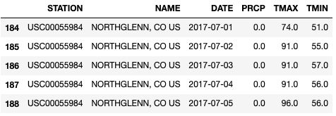

```python
dfNorthglenn =  df[df.NAME == 'NORTHGLENN, CO US']

# your code here
#raise NotImplementedError

dfNorthglenn.head()   # run this line after performing the task
```

|  | STATION | NAME | DATE | PRCP | TMAX | TMIN |
| --- | --- | --- | --- | --- | --- | --- |
| 184 | USC00055984 | NORTHGLENN, CO US | 2017-07-01 | 0.0 | 74.0 | 51.0 |
| 185 | USC00055984 | NORTHGLENN, CO US | 2017-07-02 | 0.0 | 91.0 | 55.0 |
| 186 | USC00055984 | NORTHGLENN, CO US | 2017-07-03 | 0.0 | 91.0 | 57.0 |
| 187 | USC00055984 | NORTHGLENN, CO US | 2017-07-04 | 0.0 | 91.0 | 56.0 |
| 188 | USC00055984 | NORTHGLENN, CO US | 2017-07-05 | 0.0 | 96.0 | 56.0 |

### Exercise 2

Pandas (and Numpy) have canned functions that compute each of the summary statistics discussed in lecture. You use the .mean( ) function as an example. All of these functions can be called either on a Pandas Series (i.e. a column of a DataFrame) or on an entire DataFrame at one time.

For instance, the sample mean of the maximum daily temperature is given by:

```python
dfNorthglenn["TMAX"].mean()
```

```
92.33333333333333
```

Let us observe what happens if we call .mean( ) on the entire DataFrame.

```python
# Using this code below, it will select only the numerical values within the data frame
dfNorthglenn = dfNorthglenn.select_dtypes(include='number')

# Calculate the mean values now
mean_vals = dfNorthglenn.mean()
# your code here
#raise NotImplementedError

print(mean_vals)
```

```
PRCP     0.021667
TMAX    92.333333
TMIN    59.666667
dtype: float64
```

In this case, Pandas returned a Series with the means of all of the **numerical** data in the DataFrame.

Your job is to use these functions to compute the 5-number summary for the maximum daily temperature for `dfNorthglenn`

```python
# Use the following outputs
# STEP 1: 'minval' , 'maxval' , 'Q1', 'Q2', 'Q3'
# STEP 2: then print out using the following code: print("5-Number Summary: {:.2f}    {:.2f}    {:.2f}    {:.2f}

minval = dfNorthglenn["TMAX"].min()
maxval = dfNorthglenn["TMAX"].max()
Q1 = dfNorthglenn["TMAX"].quantile(.25)
Q2 = dfNorthglenn["TMAX"].median()
Q3 = dfNorthglenn["TMAX"].quantile(.75)

# your code here
#raise NotImplementedError

print("5-Number Summary: {:.2f}    {:.2f}    {:.2f}    {:.2f}    {:.2f}".format(minval, Q1, Q2, Q3, maxval))
```

```
5-Number Summary: 74.00    89.25    93.00    98.00    101.00
```

### Exercise 3

It turns out that Pandas has a nice function called .describe( ) that will compute all of the standard summary statistics for you. You can apply it either to a Pandas Series or to an entire DataFrame.

Run the .describe( ) function on the **TMAX** column of your DataFrame `dfNorthglenn`, and check that the results agree with your computations from Exercise 2.

```python
tmax = dfNorthglenn["TMAX"].describe()

# your code here
#raise NotImplementedError

print(tmax)
```

```
count     30.000000
mean      92.333333
std        7.345340
min       74.000000
25%       89.250000
50%       93.000000
75%       98.000000
max      101.000000
Name: TMAX, dtype: float64
```

```python
### BGEIN HIDDEN TESTS

assert (tmax.size == 8, "")
```

### Exercise 4

In this exercise we'll explore how the mean and the standard deviation change when we perform basic transformations on the data. In particular, we're interested in what happens if we

1. Add or subtract some value from every entry in the data set
2. Multiply every entry in the data set by some value

We know from above that the mean and standard deviation of the `Northglenn` **TMAX** value are 92.333 and 7.345340. Experiment by **adding** and **multiplying** an integer of the value of `3` with the **TMAX** column and then recomputing the statistics. You will have 4 computations for `mean()`, `std()`, `mean()`, and `std()`. Use the `print` functions to display your 4 computaions

```python
new_tmax = dfNorthglenn["TMAX"] + 3
new_tmax_mean_add_3 = new_tmax.mean()
new_tmax_std_add_3 = new_tmax.std()

new_tmax = dfNorthglenn["TMAX"] * 3
new_tmax_mean_multiply_3 = new_tmax.mean()
new_tmax_std_multiply_3 = new_tmax.std()

# your code here
# raise NotImplementedError
```

See if you can prove that your guess works in general mathematically using the formulas for the two statistics: For your personal work, education and observation. Not graded.

$$ \bar{x} = \frac{1}{n} \displaystyle\sum_{k=1}^n x_k \quad \quad \textrm{and} \quad \quad s = \sqrt{\frac{1}{n-1} \sum_{k=1}^n \left( x_k - \bar{x}\right)^2} $$

**Solution**:

**The Mean with Addition**: It appears that when we add a constant to each observation the constant also gets added to the mean. We can show this in general as follows. Let $y_k = x_k + a$ be the shifted observations. We then have

$$ \bar{y} = \frac{1}{n} \sum_{k=1}^n y_k \quad = \quad \frac{1}{n} \sum_{k=1}^n (x_k + a) \quad = \quad \frac{1}{n} \sum_{k=1}^n x_k + \frac{1}{n} \sum_{k=1}^n a \quad = \quad \bar{x} + \frac{1}{n} \cdot an \quad = \quad \bar{x} + a $$

**The Std Dev with Addition**: On the contary, it appears that the standard deviation stays the same when we add a constant to each observation. This should make intuitive sense because the std dev is a measure of the spread of the data, and by adding a constant to each observation we're just shifting things down the number line. Let's see if we can use the formula for std dev to confirm this mathematically.

$$ \sqrt{\frac{1}{n-1}\sum_{k=1}^n \left( y_k - \bar{y} \right)^2 } \quad = \quad \sqrt{\frac{1}{n-1}\sum_{k=1}^n \left[ (x_k + a) - (\bar{x}+a) \right]^2 } \quad = \quad \sqrt{\frac{1}{n-1}\sum_{k=1}^n \left( x_k - \bar{x} \right)^2 } $$

We thus see that the standard deviation of both the $x$'s and the $y$'s are the same.

**The Mean with Multiplication**: When we multiply each observation by a constant the mean also gets multiplied by the constant. We can show this in general as follows. Let $z_k = b \cdot x_k$ be the multiplied observations. We then have

$$ \bar{z} = \frac{1}{n} \sum_{k=1}^n z_k \quad = \quad \frac{1}{n} \sum_{k=1}^n b \cdot x_k \quad = \quad b \cdot \frac{1}{n} \sum_{k=1}^n x_k \quad = \quad b\cdot \bar{x} $$

**The Std Dev with Addition**: Further, std dev gets multiplied by the constant. Let's see

$$ \sqrt{\frac{1}{n-1}\sum_{k=1}^n \left( z_k - \bar{z} \right)^2 } \quad = \quad \sqrt{\frac{1}{n-1}\sum_{k=1}^n \left( b\cdot x_k - b\cdot \bar{x} \right)^2 } \quad = \quad \sqrt{\frac{1}{n-1}\sum_{k=1}^n b^2 \cdot \left( x_k - \bar{x} \right)^2 } \quad = \quad b\cdot \sqrt{\frac{1}{n-1}\sum_{k=1}^n \left( x_k - \bar{x} \right)^2 } $$

This has thus been Confirmed.

### Exercise 5

Let us now apply a common transformation to the **TMAX** and **TMIN** columns by converting the temperatures from Fahrenheit to Celsius. Remember that the transformation is given by:

$$ \textrm{CELSIUS} = \frac{5}{9} (\textrm{FAHRENHEIT}-32) $$

First, use the Fahrenheit data in columns **TMAX** and **TMIN** to create Celsius columns in the `Northglenn` DataFrame called **TMAX-C** and **TMIN-C**. Use the `.loc` function to achieve this and print out your results using `dfNorthglenn.head()`.

```python
# your code here
#raise NotImplementedError
dfNorthglenn.loc[:, 'TMAX-C'] = 5*(dfNorthglenn['TMAX'] - 32)/9
dfNorthglenn.loc[:, 'TMIN-C'] = 5*(dfNorthglenn['TMIN'] - 32)/9
dfNorthglenn.head()
```

[output not shown]

From the material from Exercise 4, what do you expect the mean and the standard deviation of the daily maximum temperature to be in Celsius?

Calculate `y_min` and `y_max`.

$$ \bar{y}^{min} = \frac{5}{9}\left( \bar{x}^{min} - 32 \right) \\ \bar{y}^{max} = \frac{5}{9}\left( \bar{x}^{max} - 32 \right) $$

Your two output values should be of the form Calculate `y_min` and `y_max`.

Once you've done your calculation, see if you're right by applying the .mean( ) method to **TMAX-C** and **TMIN-C**. Your two output values should be `ybar_min` and `ybar_max`. Make sure again to use the `dfNorthglenn` data set.

```python
ybar_min = 5*(dfNorthglenn['TMIN'].mean()-32)/9
ybar_max = 5*(dfNorthglenn['TMAX'].mean()-32)/9

# your code here
#raise NotImplementedError

print("Mean Min Temp in Celsius = {:.3f}".format(ybar_min))
print("Mean Max Temp in Celsius = {:.3f}".format(ybar_max))
```

```
Mean Min Temp in Celsius = 15.370
Mean Max Temp in Celsius = 33.519
```

### Exercise 6

(a) Compute the daily temperature range (max **minus** min) in Fahrenheit for each row in the `Northglenn` DataFrame and store it in a column called **TDIFF**. Then answer these questions. Use the `iloc` function to do this. This is just one line of code. Display your results using the `dfNorthglenn.head()` output.

(b) What is the mean temperature difference over the month of July?

(c) What is the difference between the means of the max and min daily temperatures?

(d) Do you see a relationship between these two quantities? If so, can you prove that it's always the case for mean difference and difference of means? (open ended question). This will be show to you.

```python
# PART A
# your code here
#raise NotImplementedError
dfNorthglenn['TDIFF'] = dfNorthglenn['TMAX'] - dfNorthglenn['TMIN']
dfNorthglenn.head()
```

[output not shown]

To compute the mean temperature difference we just need to compute the mean of the **TDIFF** column we just created. Use the output `mean_diff` and run the line of code `print("Mean Temp Diff = {:.3f}".format(mean_diff))` to print out youre result!

```python
# PART B
mean_diff = dfNorthglenn['TDIFF'].mean()

# your code here
#raise NotImplementedError

print("Mean Temp Diff = {:.3f}".format(mean_diff))
```

```
Mean Temp Diff = 32.667
```

You now compute the difference of the **max** and **min** temperature means from the `dfNorthglenn` data frame. Use the output `diff_of_means` and print your results out with the following line of code `print("Diff of Mean Temps = {:.3f}".format(diff_of_means))`

```python
# PART C
diff_of_means = dfNorthglenn['TMAX'].mean() - dfNorthglenn['TMIN'].mean()

# your code here
#raise NotImplementedError

print("Diff of Mean Temps = {:.3f}".format(diff_of_means))
```

```
Diff of Mean Temps = 32.667
```